# VLM Wrong Predictions: bridge_type

**Model:** DINOv3 + Logistic Regression  
**Attribute:** bridge_type  
**Wrong assets:** 89 of 612 (14.5% asset-level error rate)

Asset 85171 1 image

Predicted: Beam (conf: N/A)

Actual: Truss

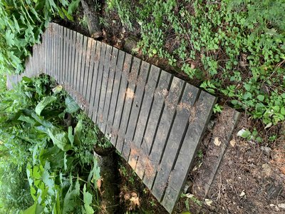

11471__AST_IM_20210804_124101.jpeg

Asset 110992 1 image

Predicted: Truss (conf: N/A)

Actual: Beam

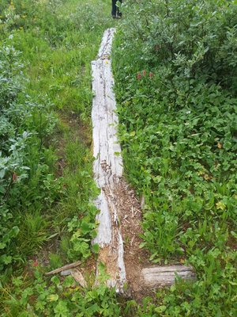

72301__MI_20240808_111405.jpg

Asset 128876 1 image

Predicted: Beam (conf: N/A)

Actual: Truss

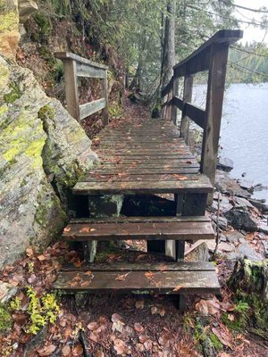

91008__AST_IM_20251122_104410.jpeg

Asset 57834 2 images

Predicted: Truss (conf: N/A)

Actual: Beam

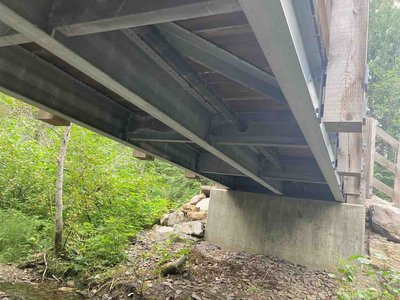

61100__AST_EX_20220824_140932.jpeg

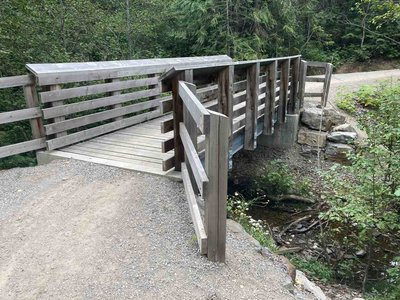

61123__AST_EX_20220824_140905.jpeg

Asset 57858 1 image

Predicted: Beam (conf: N/A)

Actual: Truss

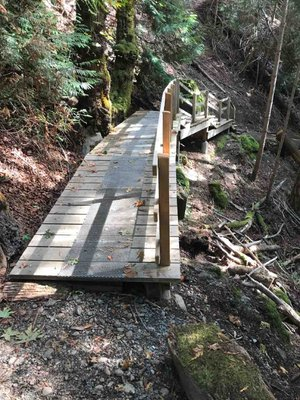

23608__AST_EX_20210924_125508.jpeg

Asset 58161 2 images

Predicted: Truss (conf: N/A)

Actual: Beam

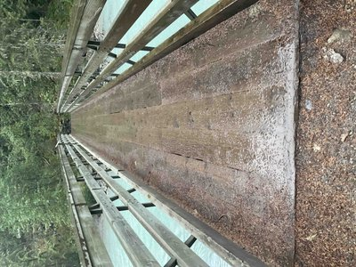

8014__AST_EX_20210725_161106.jpeg

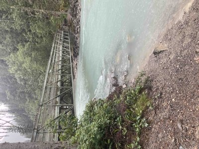

8015__AST_EX_20210725_161045.jpeg

Asset 64126 2 images

Predicted: Beam (conf: N/A)

Actual: Fallen Tree

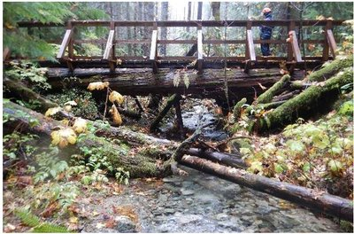

85871__asset64126-2.jpg

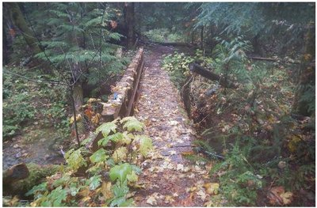

85872__asset64126.jpg

Asset 65423 1 image

Predicted: Truss (conf: N/A)

Actual: Beam

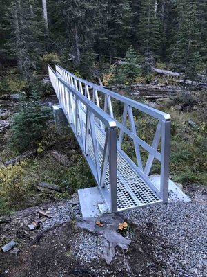

22109__AST_EX_20210916_081727.jpeg

Asset 85149 1 image

Predicted: Beam (conf: N/A)

Actual: Truss

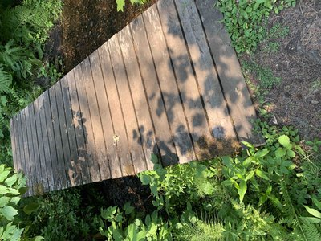

11468__AST_IM_20210804_124818.jpeg

Asset 91832 1 image

Predicted: Beam (conf: N/A)

Actual: Truss

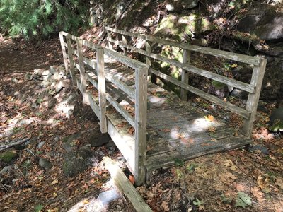

26360__IMG_1112.JPEG

Asset 105440 1 image

Predicted: Fallen Tree (conf: N/A)

Actual: Beam

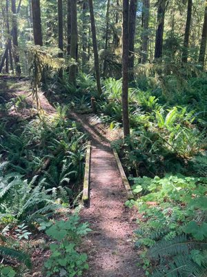

51269__AST_IM_20220626_161100.jpeg

Asset 107885 2 images

Predicted: Truss (conf: N/A)

Actual: Beam

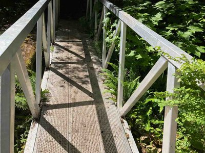

54959__AST_IM_20220720_155827.jpeg

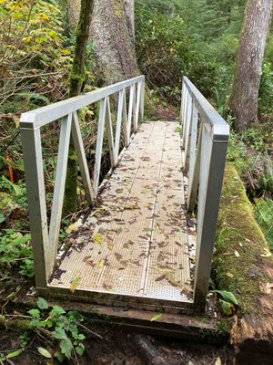

76402__AST_EX_20241025_105426.jpeg

Asset 107955 1 image

Predicted: Truss (conf: N/A)

Actual: Beam

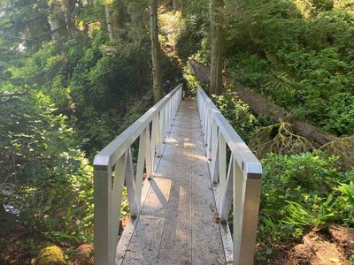

55169__AST_IM_20220720_153434.jpeg

Asset 114768 3 images

Predicted: Truss (conf: N/A)

Actual: Beam

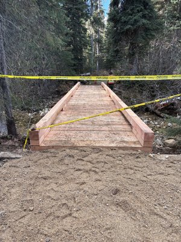

90073__IMG_6670.jpg

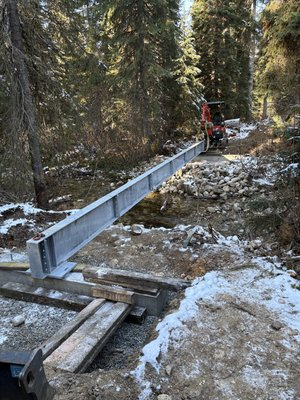

90074__IMG_6664.jpg

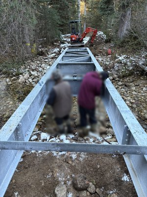

90075__IMG_6665.jpg

Asset 121618 4 images

Predicted: Beam (conf: N/A)

Actual: Truss

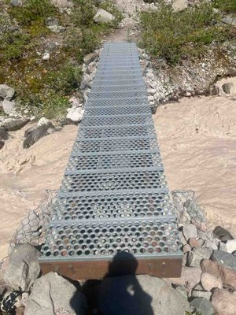

72114__AST_IM_20240803_115637.jpeg

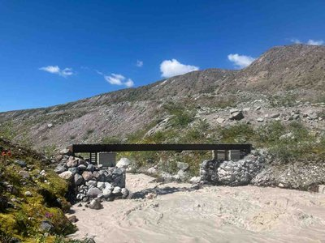

72119__AST_IM_20240803_115627.jpeg

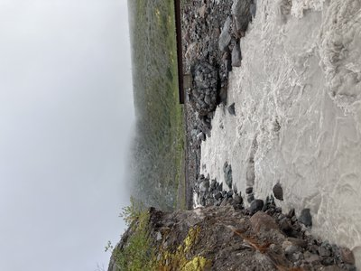

89897__Channel_view_lower_water.jpeg

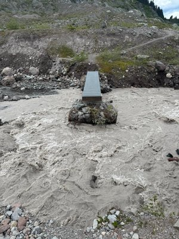

89898__Bridge_elfin_side_-_high_water.jpeg

Asset 127147 1 image

Predicted: Beam (conf: N/A)

Actual: Other

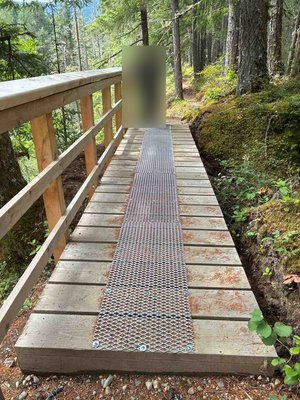

87009__AST_IM_20250819_133749.jpeg

Asset 48112 1 image

Predicted: Beam (conf: N/A)

Actual: Truss

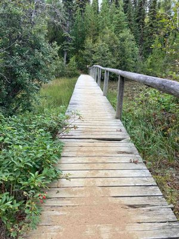

73499__AST_EX_20240913_141001.jpeg

Asset 51525 4 images

Predicted: Beam (conf: N/A)

Actual: Suspension

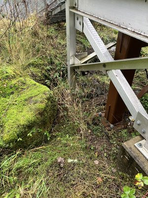

78461__IMG_0050.JPEG

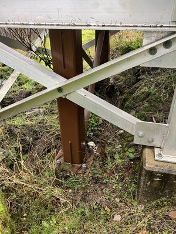

78462__IMG_0051.JPEG

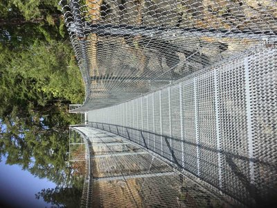

16890__AST_EX_20210820_130254.jpeg

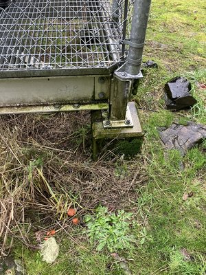

78463__IMG_0052.JPEG

Asset 51800 7 images

Predicted: Beam (conf: N/A)

Actual: Truss

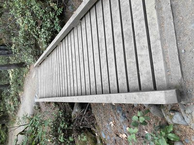

16817__AST_EX_20210820_130839.jpeg

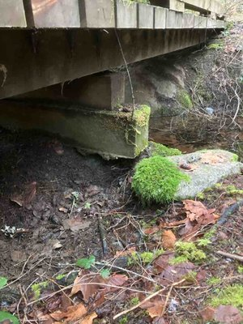

78655__AST_EX_20250123_153640.jpeg

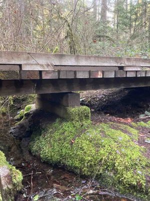

78657__AST_EX_20250123_153603.jpeg

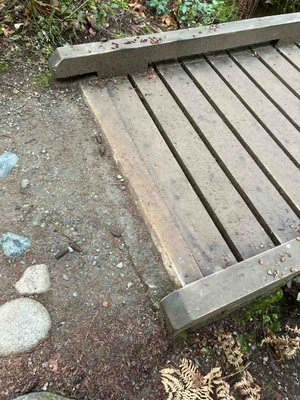

78658__AST_EX_20250123_153547.jpeg

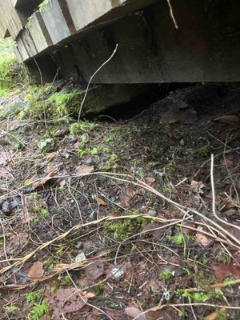

78654__AST_EX_20250123_153654.jpeg

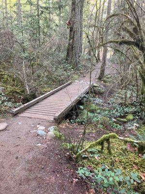

78665__AST_EX_20250123_153537.jpeg

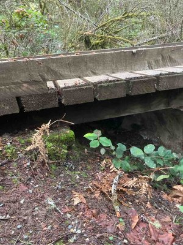

78663__AST_EX_20250123_153553.jpeg

Asset 52457 1 image

Predicted: Truss (conf: N/A)

Actual: Beam

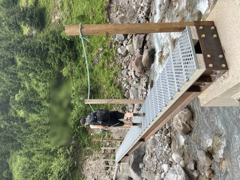

77956__IMG_3182.jpg

Asset 54683 1 image

Predicted: Beam (conf: N/A)

Actual: Truss

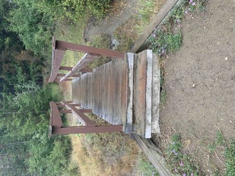

16659__AST_EX_20210819_121034.jpeg

Asset 56533 2 images

Predicted: Truss (conf: N/A)

Actual: Beam

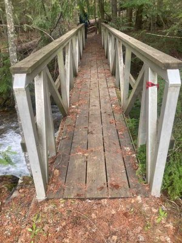

41111__AST_EX_20220512_124053.jpeg

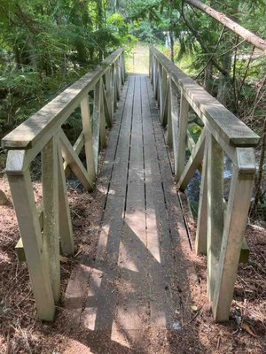

72330__AST_EX_20240811_112412.jpeg

Asset 58160 10 images

Predicted: Beam (conf: N/A)

Actual: Truss

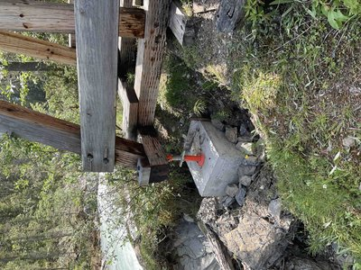

8158__AST_EX_20210727_134921.jpeg

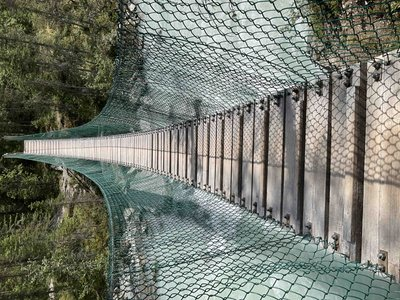

8159__AST_EX_20210727_134836.jpeg

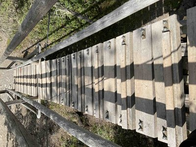

8160__AST_EX_20210727_134827.jpeg

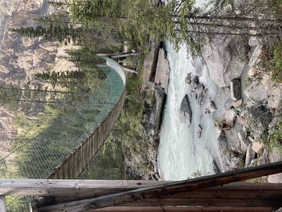

8161__AST_EX_20210727_134646.jpeg

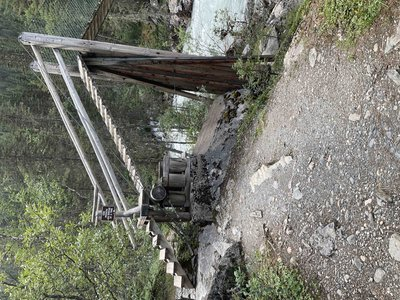

8162__AST_EX_20210727_134633.jpeg

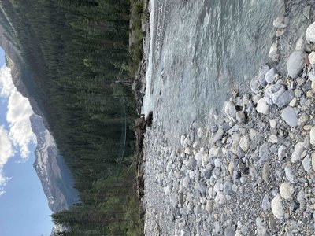

8163__AST_EX_20210727_133917.jpeg

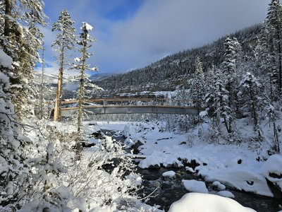

67242__20231125_112131.jpg

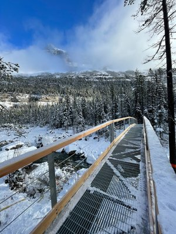

67243__IMG_2462.JPG

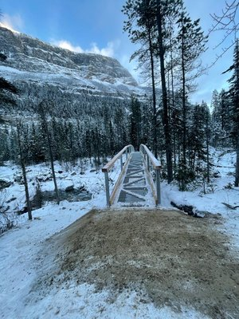

67244__IMG_2474.JPG

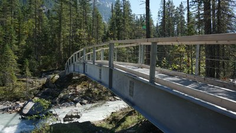

79620__New_Whitehorn_bridge.JPG

Asset 58163 1 image

Predicted: Suspension (conf: N/A)

Actual: Beam

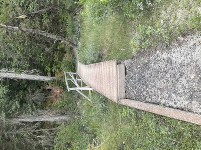

8003__AST_EX_20210725_155454.jpeg

Asset 64109 1 image

Predicted: Beam (conf: N/A)

Actual: Truss

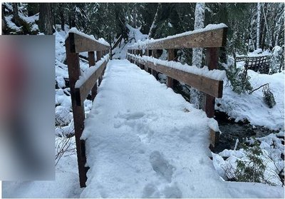

86556__asset64109.jpg

Asset 91248 2 images

Predicted: Truss (conf: N/A)